# Models

### MLR-1

MLR with all attributes , check p-Value, AIC, BIC.  
Summary of the model:

```
##
## Call:
## lm(formula = liver_fat ~ ., data = train_lin)
##
## Residuals:
##     Min      1Q  Median      3Q     Max
## -7.8279 -1.3948 -0.0406  1.3159 11.8232
##
## Coefficients: (88 not defined because of singularities)
##                          Estimate Std. Error t value Pr(>|t|)
## (Intercept)             1.151e+02  5.480e+01   2.101 0.036571 *
## age_ship_s0             2.628e-01  8.117e-01   0.324 0.746338
## female_s0              -2.014e+01  2.269e+01  -0.887 0.375621
## schul_s0                1.377e+00  8.775e-01   1.569 0.117772
## parity_w_s02           -1.861e+00  2.863e+00  -0.650 0.516143
## parity_w_s0OG                  NA         NA      NA       NA
## birth_w_s02             2.035e+00  2.291e+00   0.888 0.375314
## birth_w_s0OG                   NA         NA      NA       NA
## fruehgeb_w_s02          1.186e+00  1.746e+00   0.679 0.497606
## fruehgeb_w_s0OG                NA         NA      NA       NA
## menopaus_w_s02         -4.860e-01  1.830e+00  -0.266 0.790754
## menopaus_w_s0OG        -6.660e-01  1.667e+00  -0.400 0.689807
## menopaus_yn_w_s02              NA         NA      NA       NA
## menopaus_yn_w_s0OG             NA         NA      NA       NA
## hormonrepl_w_s02        5.994e+00  3.278e+00   1.828 0.068588 .
## hormonrepl_w_s0OG      -4.861e+00  8.760e+00  -0.555 0.579390
## pillever_w_s02         -2.134e+00  1.614e+00  -1.322 0.187259
## pillever_w_s0OG                NA         NA      NA       NA
## pillnow_w_s02           4.526e+00  3.490e+00   1.297 0.195822
## pillnow_w_s0OG                 NA         NA      NA       NA
## diabetes_s02           -1.235e+00  3.629e+00  -0.340 0.733903
## diabetes_s0None        -4.476e+00  3.548e+00  -1.262 0.208131
## smoking_s0             -5.237e-02  9.921e-01  -0.053 0.957940
## kaffee_s0              -6.083e-02  1.083e-01  -0.561 0.574963
## alkligt_s0             -1.377e-02  1.311e-02  -1.050 0.294543
## abstain_s02             1.062e+00  1.459e+00   0.728 0.467349
## abstain_s0None         -8.942e+00  4.813e+00  -1.858 0.064277 .
## physact_s0              8.479e-01  5.172e-01   1.639 0.102277
## sleepp_s0              -2.490e-01  7.466e-01  -0.333 0.739036
## sleeph_s0               2.994e-02  2.454e-01   0.122 0.902995
```

[output cut: 486 more lines]

```
## som_groe_s2            -2.652e-01  6.884e-02  -3.852 0.000146 ***
## som_gew_s2              2.651e-01  4.902e-02   5.408 1.40e-07 ***
## s2_frau_03_w_s22        5.398e-01  2.576e+00   0.210 0.834194
## s2_frau_03_w_s23       -3.145e-01  2.651e+00  -0.119 0.905653
## s2_frau_03_w_s24        1.046e+00  2.766e+00   0.378 0.705505
## s2_frau_03_w_s25        2.195e+00  3.305e+00   0.664 0.507045
## s2_frau_03_w_s26       -1.276e+00  4.416e+00  -0.289 0.772768
## s2_frau_03_w_s27       -4.022e+00  5.812e+00  -0.692 0.489479
## s2_frau_03_w_s2OG       2.132e+00  3.908e+00   0.546 0.585795
## ---
## Signif. codes:  0 '***' 0.001 '**' 0.01 '*' 0.05 '.' 0.1 ' ' 1
##
## Residual standard error: 3.886 on 271 degrees of freedom
## Multiple R-squared:  0.8708, Adjusted R-squared:  0.6629
## F-statistic: 4.189 on 436 and 271 DF,  p-value: < 2.2e-16
```

The Linear Regression Model:

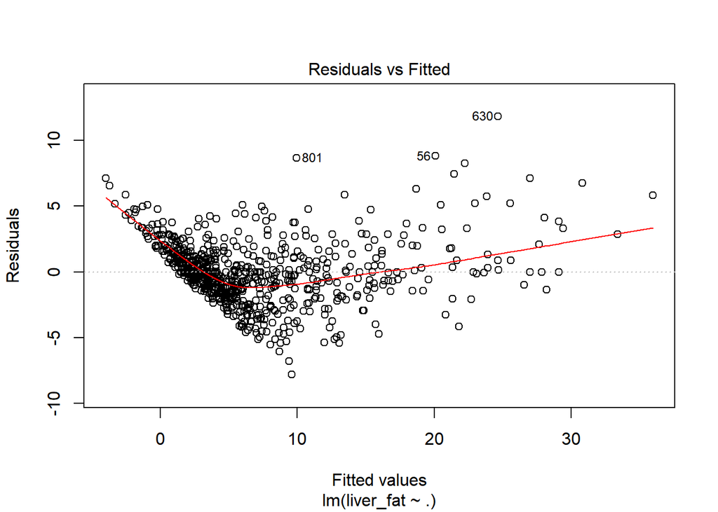

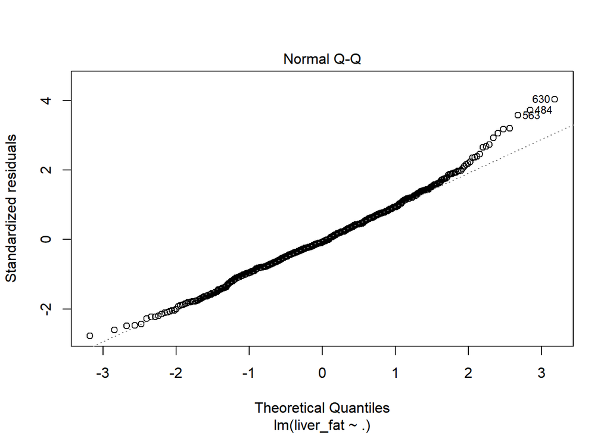

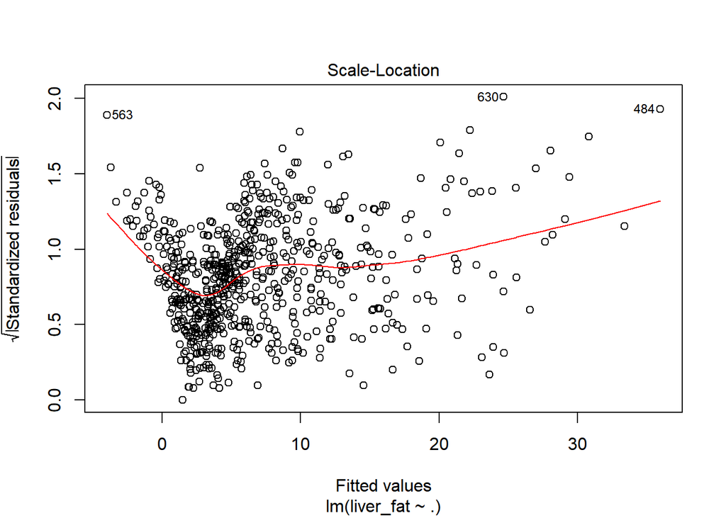

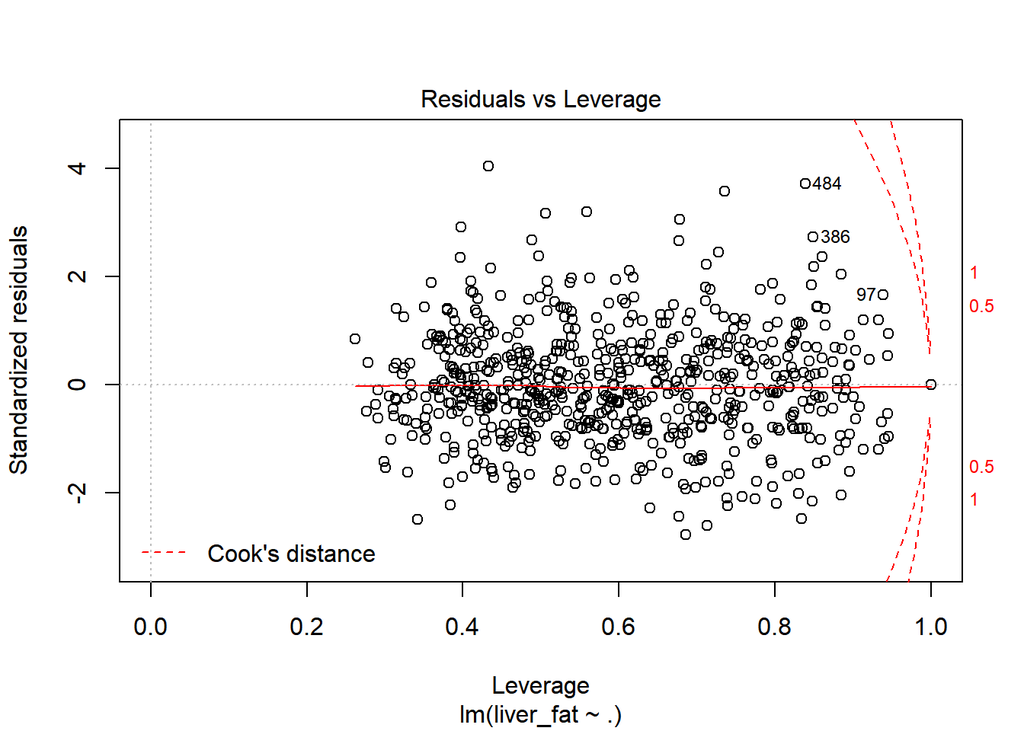

#### Observations:

Confidence Interval:

```
##                                2.5 %        97.5 %
## (Intercept)             7.243109e+00  2.230160e+02
## age_ship_s0            -1.335196e+00  1.860849e+00
## female_s0              -6.481200e+01  2.453645e+01
## schul_s0               -3.506137e-01  3.104430e+00
## parity_w_s02           -7.496660e+00  3.774511e+00
## parity_w_s0OG                     NA            NA
## birth_w_s02            -2.476077e+00  6.545222e+00
## birth_w_s0OG                      NA            NA
## fruehgeb_w_s02         -2.251573e+00  4.623219e+00
## fruehgeb_w_s0OG                   NA            NA
## menopaus_w_s02         -4.088228e+00  3.116304e+00
## menopaus_w_s0OG        -3.947560e+00  2.615615e+00
## menopaus_yn_w_s02                 NA            NA
## menopaus_yn_w_s0OG                NA            NA
## hormonrepl_w_s02       -4.601107e-01  1.244781e+01
## hormonrepl_w_s0OG      -2.210809e+01  1.238524e+01
## pillever_w_s02         -5.310654e+00  1.043602e+00
## pillever_w_s0OG                   NA            NA
## pillnow_w_s02          -2.345332e+00  1.139668e+01
## pillnow_w_s0OG                    NA            NA
## diabetes_s02           -8.378777e+00  5.909184e+00
## diabetes_s0None        -1.146070e+01  2.508292e+00
## smoking_s0             -2.005473e+00  1.900737e+00
## kaffee_s0              -2.741419e-01  1.524803e-01
## alkligt_s0             -3.958493e-02  1.204354e-02
## abstain_s02            -1.809904e+00  3.932976e+00
## abstain_s0None         -1.841864e+01  5.338945e-01
## physact_s0             -1.702948e-01  1.866019e+00
## sleepp_s0              -1.718832e+00  1.220896e+00
## sleeph_s0              -4.532228e-01  5.131004e-01
## pankr_s02              -1.077861e+01  9.239883e+00
## pankr_s0None           -1.391073e+01  2.269845e+01
## hyperlipid_s02         -3.836394e-01  4.719430e+00
## hyperlipid_s0None      -1.057692e+00  3.311921e+00
## gout_s02               -1.111004e+01 -2.091485e+00
## gout_s0None            -6.662343e+00 -4.632485e-01
## bronch_s0               1.860351e+00  7.996960e+00
## cancer_s0              -5.584332e+00  1.384182e+01
## anti_hcv_s02           -2.129415e+01  8.441957e-01
```

[output cut: 471 more lines]

```
## ges_bl_38_s24          -2.033870e+00  4.902197e+00
## ges_bl_38_s2None       -5.396437e+01 -7.854584e+00
## ges_bl_40_s22          -2.230910e+00  2.967200e-01
## ges_bl_40_s23          -2.121765e+00  2.544222e+00
## ges_bl_40_s24          -1.226332e+00  6.970524e+00
## ges_bl_40_s2None       -7.061089e+00  4.692459e+01
## som_groe_s2            -4.006808e-01 -1.296340e-01
## som_gew_s2              1.685821e-01  3.615885e-01
## s2_frau_03_w_s22       -4.532248e+00  5.611846e+00
## s2_frau_03_w_s23       -5.533011e+00  4.904086e+00
## s2_frau_03_w_s24       -4.399358e+00  6.492179e+00
## s2_frau_03_w_s25       -4.310753e+00  8.701571e+00
## s2_frau_03_w_s26       -9.970029e+00  7.417289e+00
## s2_frau_03_w_s27       -1.546433e+01  7.419814e+00
## s2_frau_03_w_s2OG      -5.561501e+00  9.825681e+00
```

#### Model comparision parameters

AIC is an estimate of a constant plus the relative distance between the unknown true likelihood function of the data and the fitted likelihood function of the model,so that a lower AIC means a model is considered to be closer to the truth.

```
## [1] 4127.304
```

BIC is an estimate of a function of the posterior probability of a model being true, under a certain Bayesian setup, so that a lower BIC means that a model is considered to be more likely to be the true model.

```
## [1] 6125.655
```

#### Graph plots

Plots to see how the model has fitted the data for certain features.  
Grey area is the confidence region.  
1. age_ship_s0

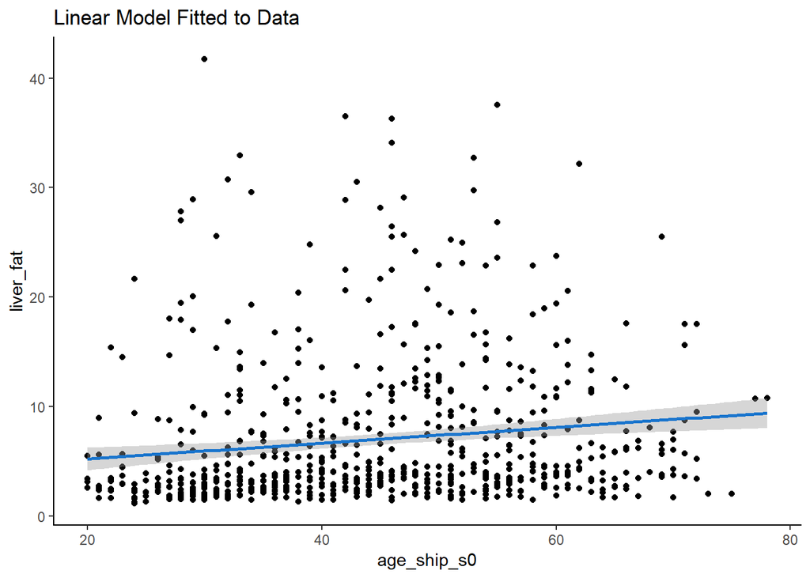

2. som_bmi_s0

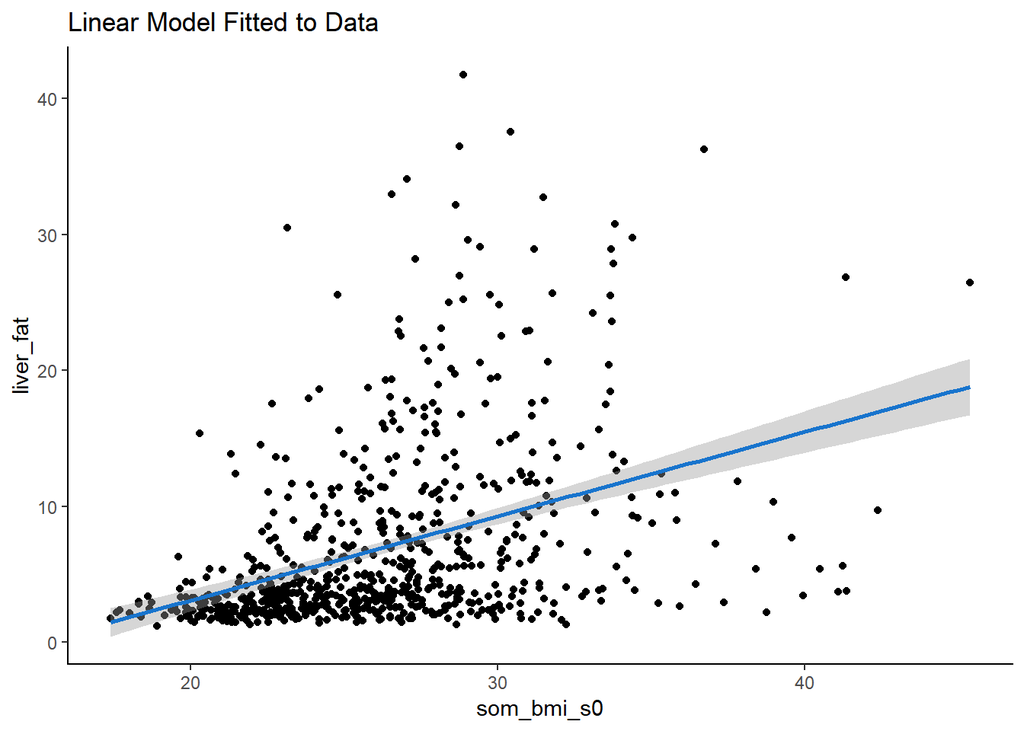

### MLR-2

The linear regression model is created, taking into consideration the important features colleced from varImp function of Random Forest.  
The summary function gives the performance summary of the model such as:Residuals, coeficients(intercept and slope for each feature), t-Value, residual standard error, Multiple R Squared value, F statistics.

```
##
## Call:
## lm(formula = liver_fat ~ ., data = train_lin2)
##
## Residuals:
##     Min      1Q  Median      3Q     Max
## -14.295  -2.409  -0.237   1.381  28.194
##
## Coefficients: (1 not defined because of singularities)
##                     Estimate Std. Error t value Pr(>|t|)
## (Intercept)        6.5659188  5.5041055   1.193  0.23333
## stea_alt75_s22     0.3676315  0.7934266   0.463  0.64327
## stea_alt75_s23     4.0397328  0.5603162   7.210 1.53e-12 ***
## stea_alt75_s24     7.0288861  0.6509293  10.798  < 2e-16 ***
## stea_alt75_s2None  1.5393532  4.7344310   0.325  0.74518
## stea_s22                  NA         NA      NA       NA
## stea_s2None        0.7823278  4.7541737   0.165  0.86934
## stea_s02           5.7562738  4.3610422   1.320  0.18731
## stea_s0None        2.7141649  3.2348584   0.839  0.40175
## stea_alt75_s02    -0.8402238  0.7028894  -1.195  0.23236
## stea_alt75_s03    -1.2692865  4.3802278  -0.290  0.77208
## stea_alt75_s04    -2.2460708  4.4107726  -0.509  0.61076
## stea_alt75_s0None -1.5544753  2.7513173  -0.565  0.57227
## som_gew_s2         0.1619244  0.0261288   6.197 1.01e-09 ***
## som_tail_s1        0.0541380  0.0496199   1.091  0.27564
## som_tail_s0        0.0068098  0.0588658   0.116  0.90794
## som_bmi_s1         0.1671958  0.1490775   1.122  0.26246
## fib_cl_s1         -0.5529771  0.2629931  -2.103  0.03587 *
## som_huef_s0       -0.0227233  0.0647842  -0.351  0.72588
## tg_s_s1            0.1136297  0.0877750   1.295  0.19592
## som_huef_s1       -0.1196293  0.0680951  -1.757  0.07941 .
## chol_hdl_s0        0.1521846  0.1727228   0.881  0.37859
## alat_s_s0          1.3481605  0.8727449   1.545  0.12289
## hrs_s_s0           0.0030079  0.0040473   0.743  0.45763
## ferri_s0           0.0007780  0.0018132   0.429  0.66800
## som_bmi_s0        -0.2069067  0.1574973  -1.314  0.18939
## crea_s_s0         -0.0234213  0.0144663  -1.619  0.10592
## age_ship0_s0       0.0073700  0.0278590   0.265  0.79144
## tg_s_s0            0.1124515  0.2246022   0.501  0.61677
## hrs_s_s1           0.0006569  0.0041279   0.159  0.87360
## op_preg_w_s02      0.0849181  1.0933771   0.078  0.93812
## op_preg_w_s03     -0.3264464  1.1835989  -0.276  0.78278
## op_preg_w_s0OG    -0.4503476  0.5740121  -0.785  0.43299
## pillnow_w_s02      0.3903879  0.6287429   0.621  0.53488
## pillnow_w_s0OG    -3.2459664  0.8616933  -3.767  0.00018 ***
## waiidf_s0         -0.1423455  0.6190811  -0.230  0.81822
## sysbp_s0           0.0006080  0.0116339   0.052  0.95834
## stmean_s0         -0.2799842  0.4307224  -0.650  0.51589
## avmeanapp_s0       0.1721489  0.1767540   0.974  0.33044
## mac_s02           -1.4570382  1.7049718  -0.855  0.39309
## mac_s0None        -1.2194776  0.6241144  -1.954  0.05113 .
## ffs_s0            -0.1084643  0.0566687  -1.914  0.05605 .
## ca_s_s0           -0.0437460  1.6429607  -0.027  0.97877
## ---
## Signif. codes:  0 '***' 0.001 '**' 0.01 '*' 0.05 '.' 0.1 ' ' 1
##
## Residual standard error: 4.667 on 666 degrees of freedom
## Multiple R-squared:  0.5419, Adjusted R-squared:  0.5137
## F-statistic: 19.21 on 41 and 666 DF,  p-value: < 2.2e-16
```

Plotting the model2 (MLR-2):

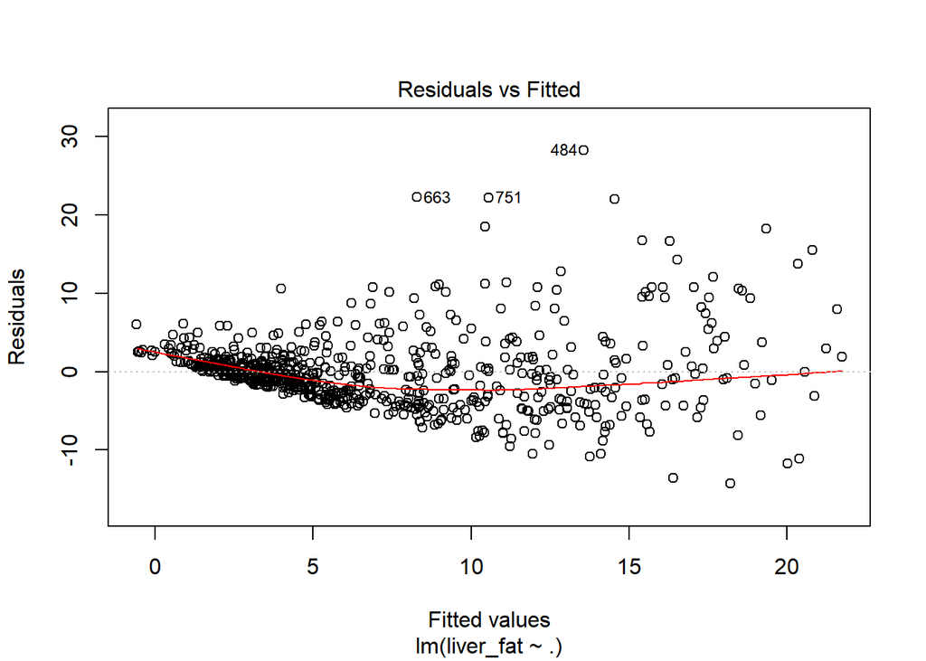

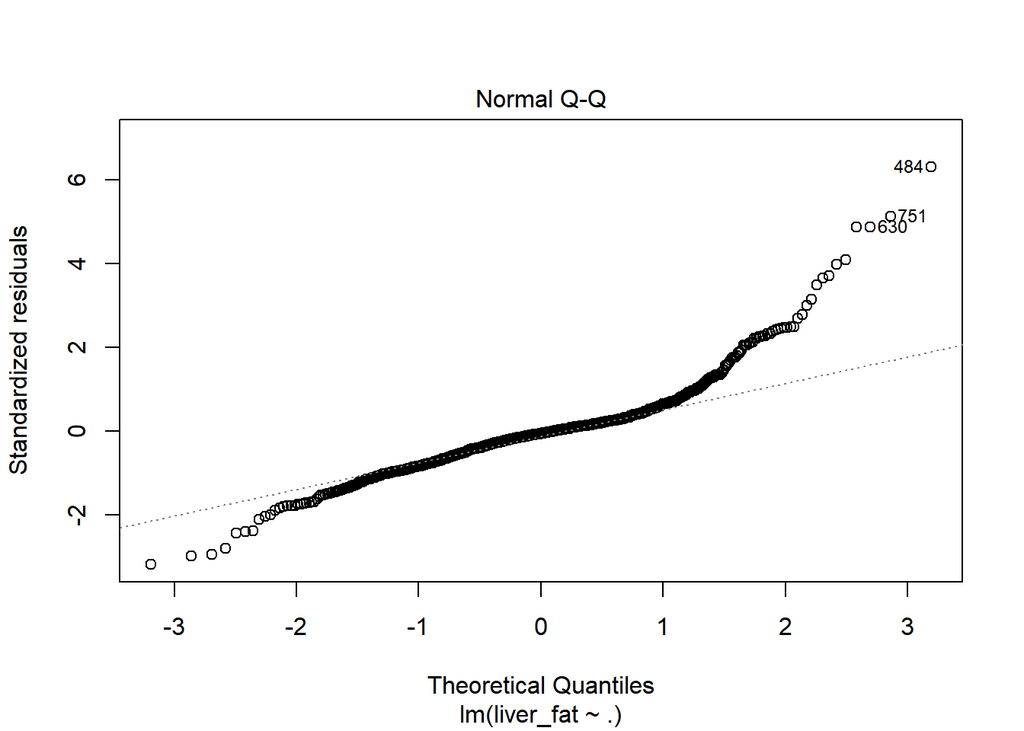

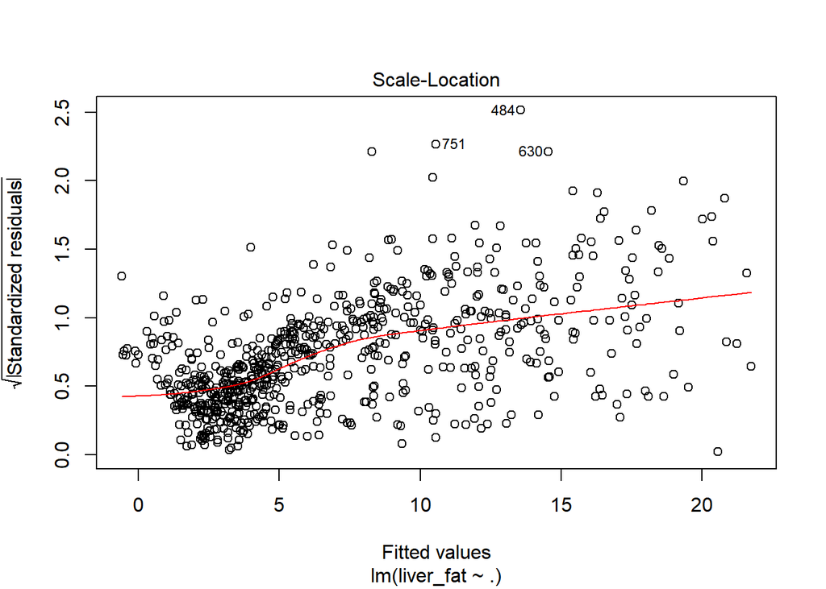

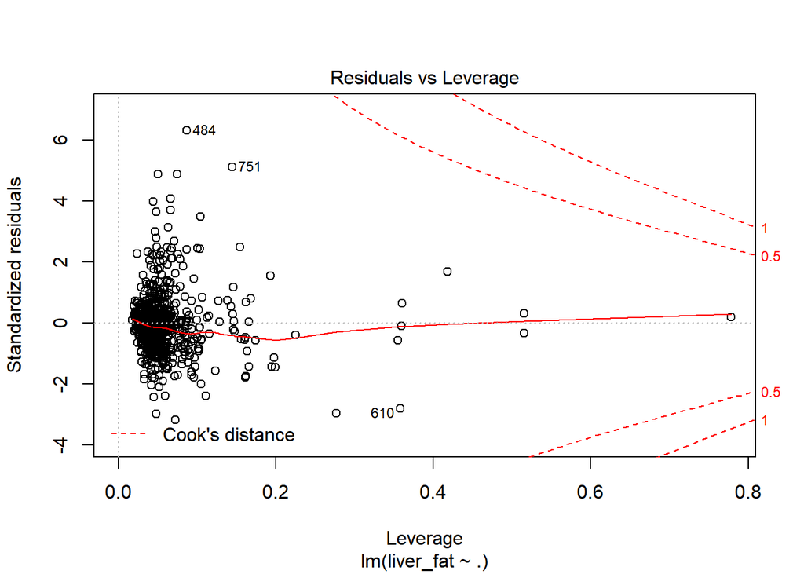

#### Observations:

```
##                           2.5 %       97.5 %
## (Intercept)        -4.241570290 17.373407925
## stea_alt75_s22     -1.190287197  1.925550230
## stea_alt75_s23      2.939533825  5.139931847
## stea_alt75_s24      5.750765384  8.307006755
## stea_alt75_s2None  -7.756855075 10.835561558
## stea_s22                     NA           NA
## stea_s2None        -8.552645852 10.117301526
## stea_s02           -2.806773590 14.319321218
## stea_s0None        -3.637584141  9.065913936
## stea_alt75_s02     -2.220369880  0.539922246
## stea_alt75_s03     -9.870005354  7.331432386
## stea_alt75_s04    -10.906765312  6.414623673
## stea_alt75_s0None  -6.956775718  3.847825142
## som_gew_s2          0.110619615  0.213229106
## som_tail_s1        -0.043292301  0.151568316
## som_tail_s0        -0.108775101  0.122394799
## som_bmi_s1         -0.125522580  0.459914235
## fib_cl_s1          -1.069372615 -0.036581671
## som_huef_s0        -0.149929103  0.104482591
## tg_s_s1            -0.058719366  0.285978803
## som_huef_s1        -0.253336292  0.014077706
## chol_hdl_s0        -0.186962126  0.491331360
## alat_s_s0          -0.365502378  3.061823328
## hrs_s_s0           -0.004939074  0.010954950
## ferri_s0           -0.002782206  0.004338194
## som_bmi_s0         -0.516157816  0.102344345
## crea_s_s0          -0.051826345  0.004983749
## age_ship0_s0       -0.047331976  0.062071952
## tg_s_s0            -0.328562094  0.553465182
## hrs_s_s1           -0.007448237  0.008762101
## op_preg_w_s02      -2.061963115  2.231799343
## op_preg_w_s03      -2.650481194  1.997588370
## op_preg_w_s0OG     -1.577438868  0.676743749
## pillnow_w_s02      -0.844169039  1.624944812
## pillnow_w_s0OG     -4.937929015 -1.554003856
## waiidf_s0          -1.357931289  1.073240210
## sysbp_s0           -0.022235510  0.023451457
## stmean_s0          -1.125721498  0.565753178
## avmeanapp_s0       -0.174913344  0.519211185
## mac_s02            -4.804805416  1.890728995
## mac_s0None         -2.444946319  0.005991140
## ffs_s0             -0.219735056  0.002806426
## ca_s_s0            -3.269752519  3.182260499
```

#### Model Comparison Parameters.

AIC is an estimate of a constant plus the relative distance between the unknown true likelihood function of the data and the fitted likelihood function of the model,so that a lower AIC means a model is considered to be closer to the truth.

```
## [1] 4233.438
```

BIC is an estimate of a function of the posterior probability of a model being true, under a certain Bayesian setup, so that a lower BIC means that a model is considered to be more likely to be the true model.

```
## [1] 4429.623
```

### MLR-3

In this approach, we use all the features selected by the Boruta Method.  
The summary function gives the performance summary of the model such as:Residuals, coeficients(intercept and slope for each feature), t-Value, Residual standard error, Multiple R Squared value, F statistics

```
##
## Call:
## lm(formula = liver_fat ~ ., data = train_lin3)
##
## Residuals:
##      Min       1Q   Median       3Q      Max
## -13.1381  -2.4424  -0.3158   1.7780  22.8575
##
## Coefficients: (6 not defined because of singularities)
##                      Estimate Std. Error t value Pr(>|t|)
## (Intercept)         3.1641504  5.6687766   0.558 0.576920
## age_ship_s0         0.0424771  0.2978578   0.143 0.886644
## som_bmi_s0         -0.1253619  0.1572993  -0.797 0.425764
## som_tail_s0        -0.1508269  0.0563801  -2.675 0.007658 **
## som_huef_s0         0.0807057  0.0644449   1.252 0.210906
## hrs_s_s0            0.0009961  0.0040912   0.243 0.807713
## asat_s_s0          -2.7909164  1.8396120  -1.517 0.129724
## alat_s_s0           2.8138352  1.1172591   2.519 0.012025 *
## ggt_s_s0           -0.1149818  0.1898037  -0.606 0.544864
## tg_s_s0             0.0365474  0.2272212   0.161 0.872266
## ferri_s0           -0.0005631  0.0018866  -0.299 0.765415
## igf1_s0             0.0017895  0.0046004   0.389 0.697405
## stea_alt75_s02     -1.0003765  0.7027497  -1.424 0.155068
## stea_alt75_s03     -1.9783716  4.5169877  -0.438 0.661544
## stea_alt75_s04     -2.7288120  4.5467553  -0.600 0.548605
## stea_alt75_s0None  -2.1260675  2.8110903  -0.756 0.449736
## stea_s02            6.1807287  4.4958457   1.375 0.169680
## stea_s0None         3.2454504  3.3865905   0.958 0.338257
## age_ship_s1         0.0473731  0.0552884   0.857 0.391852
## som_bmi_s1          0.1828290  0.1520788   1.202 0.229726
## som_tail_s1         0.0290110  0.0507229   0.572 0.567554
## som_huef_s1        -0.0962946  0.0674008  -1.429 0.153577
## fib_cl_s1          -1.1538621  0.3080715  -3.745 0.000196 ***
## hrs_s_s1           -0.0011164  0.0042063  -0.265 0.790775
## tg_s_s1             0.1552930  0.0888857   1.747 0.081093 .
## hdl_s_s1           -0.3489878  0.4947095  -0.705 0.480790
## hs_crp_s1           0.2161155  0.0595696   3.628 0.000308 ***
## igf1_s1             0.0045291  0.0051641   0.877 0.380789
## diabetes_s22       -0.0258738  0.7928896  -0.033 0.973978
## diabetes_s2None     2.1107841  5.1838019   0.407 0.684004
```

[output cut: 28 more lines]

```
## mac_s0None         -2.9231787  2.9529575  -0.990 0.322585
## metsyn_s02          1.2999855  0.6319960   2.057 0.040091 *
## metsyn_s0None      -0.4062850  1.8059853  -0.225 0.822077
## waistc_s0           0.5061377  0.7190467   0.704 0.481748
## waiidf_s0           0.4250706  0.5971293   0.712 0.476810
## whratc_s0           2.1352249  0.7596734   2.811 0.005093 **
## antihyp_s0         -1.3100957  0.6390362  -2.050 0.040756 *
## mort_time_birth_s0 -0.0001197  0.0008239  -0.145 0.884488
## som_gew_s2          0.1282688  0.0258857   4.955 9.24e-07 ***
## ---
## Signif. codes:  0 '***' 0.001 '**' 0.01 '*' 0.05 '.' 0.1 ' ' 1
##
## Residual standard error: 4.665 on 647 degrees of freedom
## Multiple R-squared:  0.5555, Adjusted R-squared:  0.5142
## F-statistic: 13.47 on 60 and 647 DF,  p-value: < 2.2e-16
```

Plotting Model3 (MLR-3)

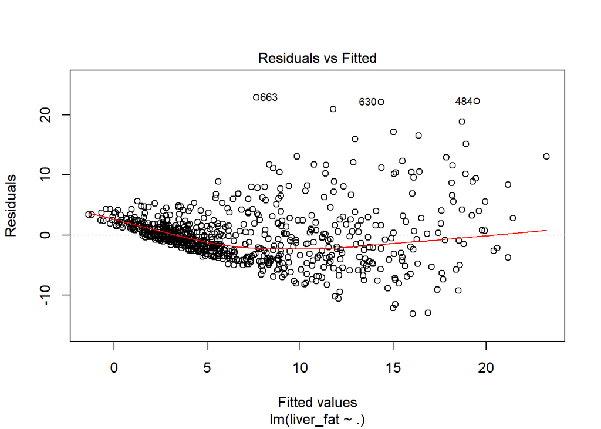

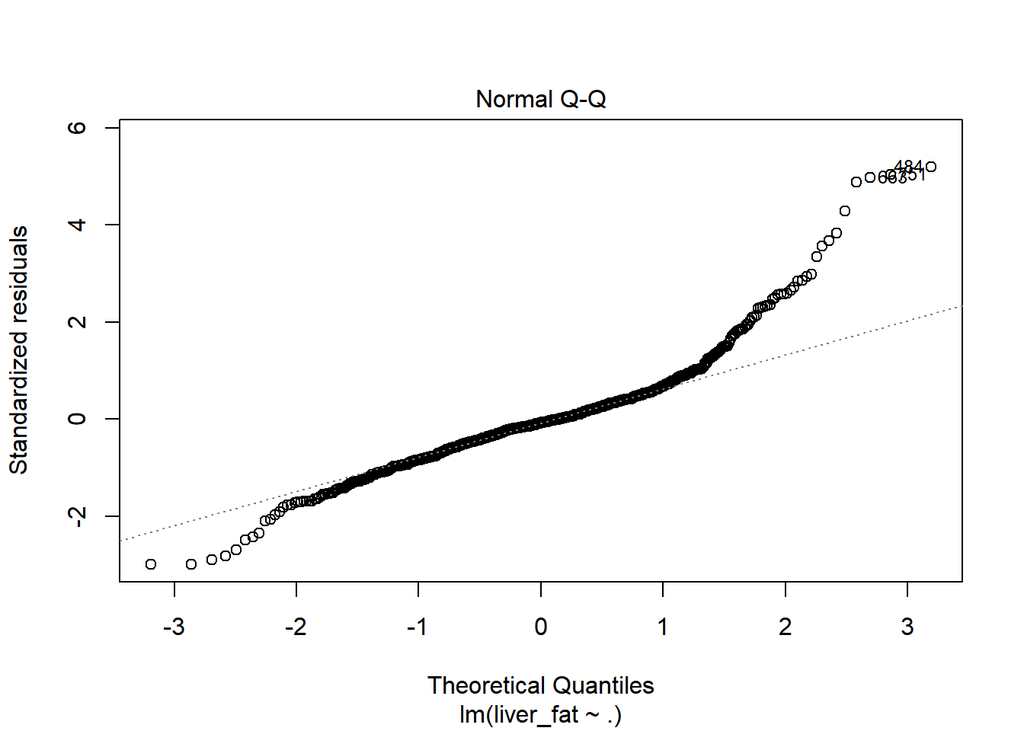

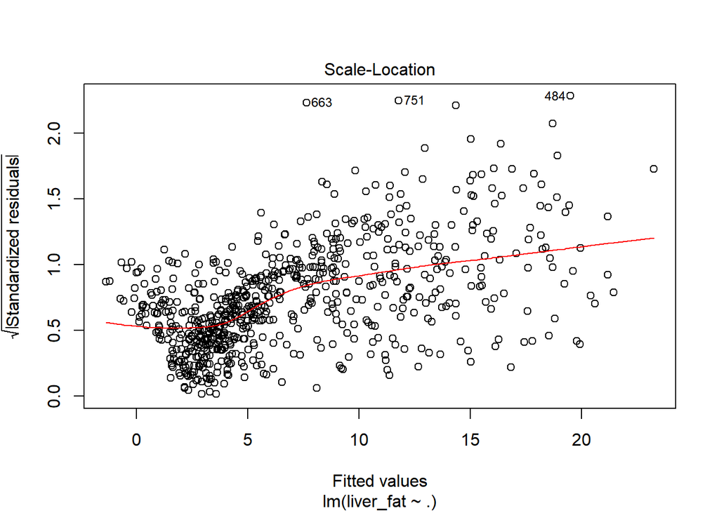

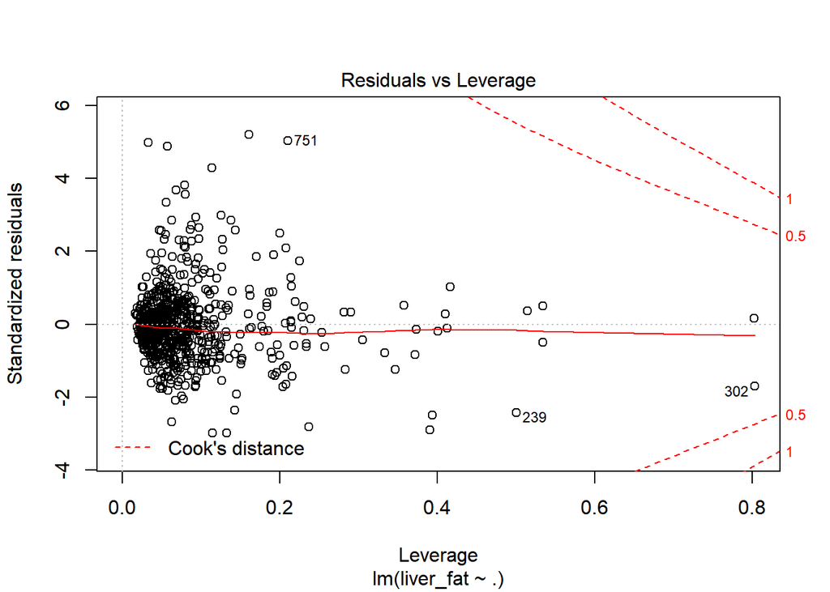

#### Observations:

Confidence Interval:

```
##                            2.5 %       97.5 %
## (Intercept)         -7.967270906 14.295571669
## age_ship_s0         -0.542407636  0.627361781
## som_bmi_s0          -0.434240608  0.183516904
## som_tail_s0         -0.261536895 -0.040116817
## som_huef_s0         -0.045840769  0.207252082
## hrs_s_s0            -0.007037445  0.009029656
## asat_s_s0           -6.403247152  0.821414449
## alat_s_s0            0.619943671  5.007726781
## ggt_s_s0            -0.487687365  0.257723735
## tg_s_s0             -0.409632701  0.482727528
## ferri_s0            -0.004267693  0.003141398
## igf1_s0             -0.007243943  0.010823031
## stea_alt75_s02      -2.380322045  0.379568968
## stea_alt75_s03     -10.848097110  6.891353846
## stea_alt75_s04     -11.656990331  6.199366343
## stea_alt75_s0None   -7.646029255  3.393894294
## stea_s02            -2.647481617 15.008938974
## stea_s0None         -3.404585093  9.895485916
## age_ship_s1         -0.061193169  0.155939406
## som_bmi_s1          -0.115798539  0.481456507
## som_tail_s1         -0.070590375  0.128612394
## som_huef_s1         -0.228645401  0.036056147
## fib_cl_s1           -1.758802839 -0.548921399
## hrs_s_s1            -0.009376137  0.007143299
## tg_s_s1             -0.019246334  0.329832359
## hdl_s_s1            -1.320417807  0.622442205
## hs_crp_s1            0.099142403  0.333088539
## igf1_s1             -0.005611260  0.014669492
## diabetes_s22        -1.582821329  1.531073720
## diabetes_s2None     -8.068322685 12.289890832
## smoking_s22         -1.153410312  0.673090467
## smoking_s23         -1.485582202  0.785701297
## smoking_s2None     -25.197971448 10.245782438
## abstain_s22         -3.228730672  0.191299457
## abstain_s2None      -8.813081875 11.062916394
## hyperlipid_s22      -1.311016293  1.224760262
## hyperlipid_s2None   -1.859534642  6.084164031
## earm_s22            -2.435388452  2.373966273
## earm_s2None         -3.677949770  2.941036037
```

[output cut: 13 more lines]

```
## atc_c08ca01_s2None            NA           NA
## age_ship0_s0                  NA           NA
## diabp_s0            -0.042058260  0.034854849
## avs_s02             -1.025102987  1.986227999
## avs_s0None          -3.931329373  8.029622185
## mac_s02             -3.473468429  3.692562032
## mac_s0None          -8.721716319  2.875358887
## metsyn_s02           0.058974521  2.540996542
## metsyn_s0None       -3.952584982  3.140015054
## waistc_s0           -0.905809170  1.918084653
## waiidf_s0           -0.747474807  1.597616068
## whratc_s0            0.643501892  3.626947973
## antihyp_s0          -2.564930944 -0.055260361
## mort_time_birth_s0  -0.001737598  0.001498106
## som_gew_s2           0.077438675  0.179098890
```

AIC Value:

```
## [1] 4250.129
```

BIC Value:

```
## [1] 4533.001
```

[figure not shown]

[output not shown]

### Analysis of Variances.

In this section we will try and compare the different multiple linear regression approaches:

#### Model 1 vs Model 2

```
## Analysis of Variance Table
##
## Model 1: liver_fat ~ age_ship_s0 + female_s0 + schul_s0 + parity_w_s0 +
##     birth_w_s0 + fruehgeb_w_s0 + menopaus_w_s0 + menopaus_yn_w_s0 +
##     hormonrepl_w_s0 + pillever_w_s0 + pillnow_w_s0 + diabetes_s0 +
##     smoking_s0 + kaffee_s0 + alkligt_s0 + abstain_s0 + physact_s0 +
##     sleepp_s0 + sleeph_s0 + pankr_s0 + hyperlipid_s0 + gout_s0 +
##     bronch_s0 + cancer_s0 + anti_hcv_s0 + hbs_ag_s0 + som_bmi_s0 +
##     som_tail_s0 + som_huef_s0 + hgb_s0 + hba1c_s0 + fib_cl_s0 +
##     crea_s_s0 + hrs_s_s0 + gluc_s_s0 + asat_s_s0 + alat_s_s0 +
##     ggt_s_s0 + lip_s_s0 + chol_s_s0 + tg_s_s0 + hdl_s_s0 + ldl_s_s0 +
##     lipo_a_s0 + apoa1_s0 + apob_s0 + tsh_s0 + ferri_s0 + cdt_s0 +
##     jodid_u_s0 + crea_u_s0 + hs_crp_s0 + testo_m_s0 + dheas_m_s0 +
##     prl_s0 + igf1_s0 + igfbp3_s0 + udpdkrea_s0 + sd_volg_s0 +
##     goiter_s0 + knoten_s0 + earm_s0 + stea_alt75_s0 + stea_s0 +
##     galls_s0 + avmean_s0 + avmeanapp_s0 + stmean_s0 + stmeanapp_s0 +
##     zaehne_s0 + tonetti_s0 + page_s0 + atc_c07a_s0 + atc_c07aa_s0 +
##     atc_c07ab_s0 + atc_c08_s0 + atc_c08ca01_s0 + atc_c08ca05_s0 +
##     atc_c08ca08_s0 + atc_c08da01_s0 + atc_c09aa02_s0 + atc_c09aa05_s0 +
##     atc_h02a_s0 + age_ship_s1 + parity_w_s1 + menopaus_w_s1 +
##     menopaus_yn_w_s1 + hormonrepl_w_s1 + diabetes_s1 + smoking_s1 +
##     alkligt_s1 + abstain_s1 + hyperlipid_s1 + gout_s1 + som_bmi_s1 +
##     som_tail_s1 + som_huef_s1 + hgb_s1 + hba1c_s1 + quick_s1 +
##     fib_cl_s1 + crea_s_s1 + hrs_s_s1 + gluc_s_s1 + chol_s_s1 +
##     tg_s_s1 + hdl_s_s1 + ldl_s_s1 + tsh_s1 + jodid_u_s1 + crea_u_s1 +
##     hs_crp_s1 + testo_m_s1 + igf1_s1 + sd_volg_s1 + goiter_s1 +
##     knoten_s1 + earm_s1 + atc_c07a_s1 + atc_c07aa_s1 + atc_c07ab_s1 +
##     atc_c08_s1 + atc_c08ca01_s1 + atc_c08ca05_s1 + atc_c08ca08_s1 +
##     atc_c08da01_s1 + atc_c09aa02_s1 + atc_c09aa05_s1 + atc_h02a_s1 +
##     parity_w_s2 + fruehgeb_w_s2 + menopaus_w_s2 + menopaus_yn_w_s2 +
##     hormonrepl_w_s2 + pillever_w_s2 + pillnow_w_s2 + diabetes_s2 +
##     smoking_s2 + abstain_s2 + physact_s2 + sleepp_s2 + hyperlipid_s2 +
##     gout_s2 + goiter_s2 + knoten_s2 + earm_s2 + stea_alt75_s2 +
##     stea_s2 + atc_c07a_s2 + atc_c07aa_s2 + atc_c07ab_s2 + atc_c08_s2 +
##     atc_c08ca01_s2 + atc_c08ca05_s2 + atc_c08ca08_s2 + atc_c08da01_s2 +
##     atc_c09aa02_s2 + atc_c09aa05_s2 + atc_h02a_s2 + gx_rs11597390 +
##     gx_rs11597086 + gx_rs11591741 + gx_rs1169313 + gx_rs4820599 +
##     gx_rs738409 + gx_rs738408 + gx_rs2281135 + gx_rs2072907 +
##     gx_rs2143571 + sex_s0 + age_ship0_s0 + exloc_ship0_s0 + w_sample_s0 +
##     psu_s0 + strata1_s0 + fpc1_s0 + strata2_s0 + fpc2_s0 + marit_s0 +
```

[output cut: 31 more lines]

```
##     atc_r03d_s0 + atc_r05cb_s0 + atc_r06a_s0 + atc_s01_s0 + mort_all_s0 +
##     mort_icd10_s0 + mort_time_s0 + mort_time_birth_s0 + na_s_s0 +
##     k_s_s0 + ca_s_s0 + mg_s_s0 + ges_bl_32_s2 + ges_bl_38_s2 +
##     ges_bl_40_s2 + som_groe_s2 + som_gew_s2 + s2_frau_03_w_s2
## Model 2: liver_fat ~ stea_alt75_s2 + stea_s2 + stea_s0 + stea_alt75_s0 +
##     som_gew_s2 + som_tail_s1 + som_tail_s0 + som_bmi_s1 + fib_cl_s1 +
##     som_huef_s0 + tg_s_s1 + som_huef_s1 + chol_hdl_s0 + alat_s_s0 +
##     hrs_s_s0 + ferri_s0 + som_bmi_s0 + crea_s_s0 + age_ship0_s0 +
##     tg_s_s0 + hrs_s_s1 + op_preg_w_s0 + pillnow_w_s0 + waiidf_s0 +
##     sysbp_s0 + stmean_s0 + avmeanapp_s0 + mac_s0 + ffs_s0 + ca_s_s0
##   Res.Df     RSS   Df Sum of Sq      F    Pr(>F)
## 1    271  4092.1
## 2    666 14509.1 -395    -10417 1.7465 5.456e-07 ***
## ---
## Signif. codes:  0 '***' 0.001 '**' 0.01 '*' 0.05 '.' 0.1 ' ' 1
```

Observation: Model1 is proving better for its lower value fo RSS and other attributes.

#### Model 2 vs Model 3

```
## Analysis of Variance Table
##
## Model 1: liver_fat ~ stea_alt75_s2 + stea_s2 + stea_s0 + stea_alt75_s0 +
##     som_gew_s2 + som_tail_s1 + som_tail_s0 + som_bmi_s1 + fib_cl_s1 +
##     som_huef_s0 + tg_s_s1 + som_huef_s1 + chol_hdl_s0 + alat_s_s0 +
##     hrs_s_s0 + ferri_s0 + som_bmi_s0 + crea_s_s0 + age_ship0_s0 +
##     tg_s_s0 + hrs_s_s1 + op_preg_w_s0 + pillnow_w_s0 + waiidf_s0 +
##     sysbp_s0 + stmean_s0 + avmeanapp_s0 + mac_s0 + ffs_s0 + ca_s_s0
## Model 2: liver_fat ~ age_ship_s0 + som_bmi_s0 + som_tail_s0 + som_huef_s0 +
##     hrs_s_s0 + asat_s_s0 + alat_s_s0 + ggt_s_s0 + tg_s_s0 + ferri_s0 +
##     igf1_s0 + stea_alt75_s0 + stea_s0 + age_ship_s1 + som_bmi_s1 +
##     som_tail_s1 + som_huef_s1 + fib_cl_s1 + hrs_s_s1 + tg_s_s1 +
##     hdl_s_s1 + hs_crp_s1 + igf1_s1 + diabetes_s2 + smoking_s2 +
##     abstain_s2 + hyperlipid_s2 + earm_s2 + stea_alt75_s2 + stea_s2 +
##     atc_c07a_s2 + atc_c07ab_s2 + atc_c08_s2 + atc_c08ca01_s2 +
##     age_ship0_s0 + diabp_s0 + avs_s0 + mac_s0 + metsyn_s0 + waistc_s0 +
##     waiidf_s0 + whratc_s0 + antihyp_s0 + mort_time_birth_s0 +
##     som_gew_s2
##   Res.Df   RSS Df Sum of Sq      F Pr(>F)
## 1    666 14509
## 2    647 14079 19    430.17 1.0405 0.4112
```

Observation: Almost similar, but Model 3 yields slightly better.

#### Model 1 vs Model 3

```
## Analysis of Variance Table
##
## Model 1: liver_fat ~ age_ship_s0 + som_bmi_s0 + som_tail_s0 + som_huef_s0 +
##     hrs_s_s0 + asat_s_s0 + alat_s_s0 + ggt_s_s0 + tg_s_s0 + ferri_s0 +
##     igf1_s0 + stea_alt75_s0 + stea_s0 + age_ship_s1 + som_bmi_s1 +
##     som_tail_s1 + som_huef_s1 + fib_cl_s1 + hrs_s_s1 + tg_s_s1 +
##     hdl_s_s1 + hs_crp_s1 + igf1_s1 + diabetes_s2 + smoking_s2 +
##     abstain_s2 + hyperlipid_s2 + earm_s2 + stea_alt75_s2 + stea_s2 +
##     atc_c07a_s2 + atc_c07ab_s2 + atc_c08_s2 + atc_c08ca01_s2 +
##     age_ship0_s0 + diabp_s0 + avs_s0 + mac_s0 + metsyn_s0 + waistc_s0 +
##     waiidf_s0 + whratc_s0 + antihyp_s0 + mort_time_birth_s0 +
##     som_gew_s2
## Model 2: liver_fat ~ age_ship_s0 + female_s0 + schul_s0 + parity_w_s0 +
##     birth_w_s0 + fruehgeb_w_s0 + menopaus_w_s0 + menopaus_yn_w_s0 +
##     hormonrepl_w_s0 + pillever_w_s0 + pillnow_w_s0 + diabetes_s0 +
##     smoking_s0 + kaffee_s0 + alkligt_s0 + abstain_s0 + physact_s0 +
##     sleepp_s0 + sleeph_s0 + pankr_s0 + hyperlipid_s0 + gout_s0 +
##     bronch_s0 + cancer_s0 + anti_hcv_s0 + hbs_ag_s0 + som_bmi_s0 +
##     som_tail_s0 + som_huef_s0 + hgb_s0 + hba1c_s0 + fib_cl_s0 +
##     crea_s_s0 + hrs_s_s0 + gluc_s_s0 + asat_s_s0 + alat_s_s0 +
##     ggt_s_s0 + lip_s_s0 + chol_s_s0 + tg_s_s0 + hdl_s_s0 + ldl_s_s0 +
##     lipo_a_s0 + apoa1_s0 + apob_s0 + tsh_s0 + ferri_s0 + cdt_s0 +
##     jodid_u_s0 + crea_u_s0 + hs_crp_s0 + testo_m_s0 + dheas_m_s0 +
##     prl_s0 + igf1_s0 + igfbp3_s0 + udpdkrea_s0 + sd_volg_s0 +
##     goiter_s0 + knoten_s0 + earm_s0 + stea_alt75_s0 + stea_s0 +
##     galls_s0 + avmean_s0 + avmeanapp_s0 + stmean_s0 + stmeanapp_s0 +
##     zaehne_s0 + tonetti_s0 + page_s0 + atc_c07a_s0 + atc_c07aa_s0 +
##     atc_c07ab_s0 + atc_c08_s0 + atc_c08ca01_s0 + atc_c08ca05_s0 +
##     atc_c08ca08_s0 + atc_c08da01_s0 + atc_c09aa02_s0 + atc_c09aa05_s0 +
##     atc_h02a_s0 + age_ship_s1 + parity_w_s1 + menopaus_w_s1 +
##     menopaus_yn_w_s1 + hormonrepl_w_s1 + diabetes_s1 + smoking_s1 +
##     alkligt_s1 + abstain_s1 + hyperlipid_s1 + gout_s1 + som_bmi_s1 +
##     som_tail_s1 + som_huef_s1 + hgb_s1 + hba1c_s1 + quick_s1 +
##     fib_cl_s1 + crea_s_s1 + hrs_s_s1 + gluc_s_s1 + chol_s_s1 +
##     tg_s_s1 + hdl_s_s1 + ldl_s_s1 + tsh_s1 + jodid_u_s1 + crea_u_s1 +
##     hs_crp_s1 + testo_m_s1 + igf1_s1 + sd_volg_s1 + goiter_s1 +
##     knoten_s1 + earm_s1 + atc_c07a_s1 + atc_c07aa_s1 + atc_c07ab_s1 +
##     atc_c08_s1 + atc_c08ca01_s1 + atc_c08ca05_s1 + atc_c08ca08_s1 +
##     atc_c08da01_s1 + atc_c09aa02_s1 + atc_c09aa05_s1 + atc_h02a_s1 +
##     parity_w_s2 + fruehgeb_w_s2 + menopaus_w_s2 + menopaus_yn_w_s2 +
```

[output cut: 35 more lines]

```
##     atc_c09aa01_s0 + atc_c09ca_s0 + atc_c10aa_s0 + atc_c10ab_s0 +
##     atc_g03_s0 + atc_g03a_s0 + atc_g03c_s0 + atc_g03f_s0 + atc_g03h_s0 +
##     atc_g04c_s0 + atc_m01a_s0 + atc_m01ab05_s0 + atc_m01ae01_s0 +
##     atc_m04a_s0 + atc_n02a_s0 + atc_n03a_s0 + atc_n05b_s0 + atc_n05bp_s0 +
##     atc_n06a_s0 + atc_n06d_s0 + atc_n06dp01_s0 + atc_n07c_s0 +
##     atc_n07xb_s0 + atc_r01a_s0 + atc_r03_s0 + atc_r03a_s0 + atc_r03b_s0 +
##     atc_r03d_s0 + atc_r05cb_s0 + atc_r06a_s0 + atc_s01_s0 + mort_all_s0 +
##     mort_icd10_s0 + mort_time_s0 + mort_time_birth_s0 + na_s_s0 +
##     k_s_s0 + ca_s_s0 + mg_s_s0 + ges_bl_32_s2 + ges_bl_38_s2 +
##     ges_bl_40_s2 + som_groe_s2 + som_gew_s2 + s2_frau_03_w_s2
##   Res.Df     RSS  Df Sum of Sq     F    Pr(>F)
## 1    647 14078.9
## 2    271  4092.1 376    9986.8 1.759 4.888e-07 ***
## ---
## Signif. codes:  0 '***' 0.001 '**' 0.01 '*' 0.05 '.' 0.1 ' ' 1
```

Observation: Model 1 is better than Model 3.

#### Plots:

Plot1 showing comparision of 3 models.  
The more the R square value, better the model.

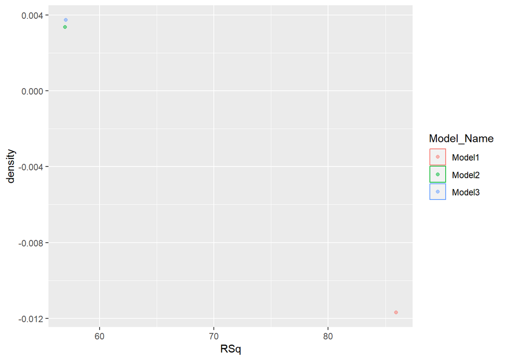

Plot2 showing comparision of 3 models. The taller the height of the bar of a model, the better it is.

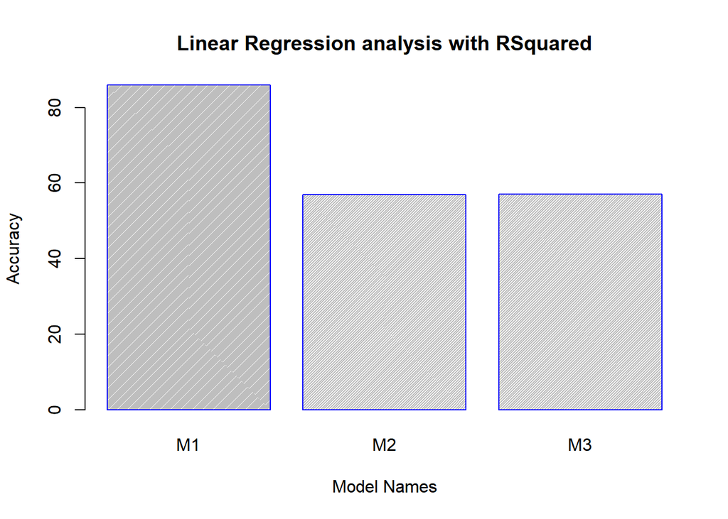

Histogram to visualize model1 If the plot is symmetrical around 0 that means the model has fit the data well

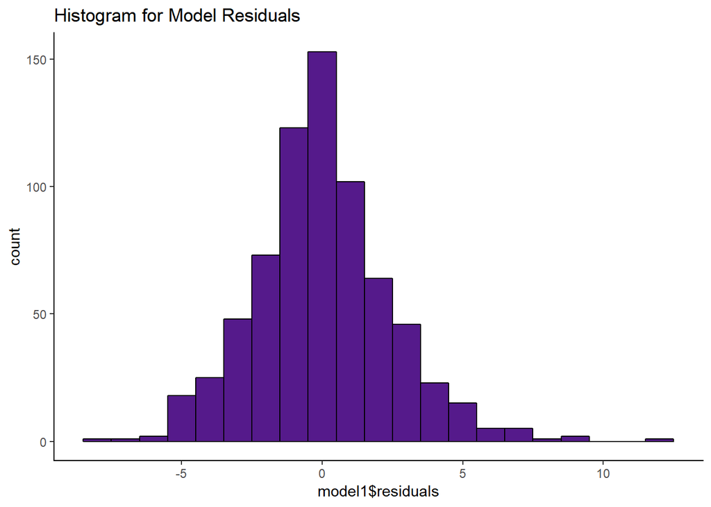

Histogram to visualize model2

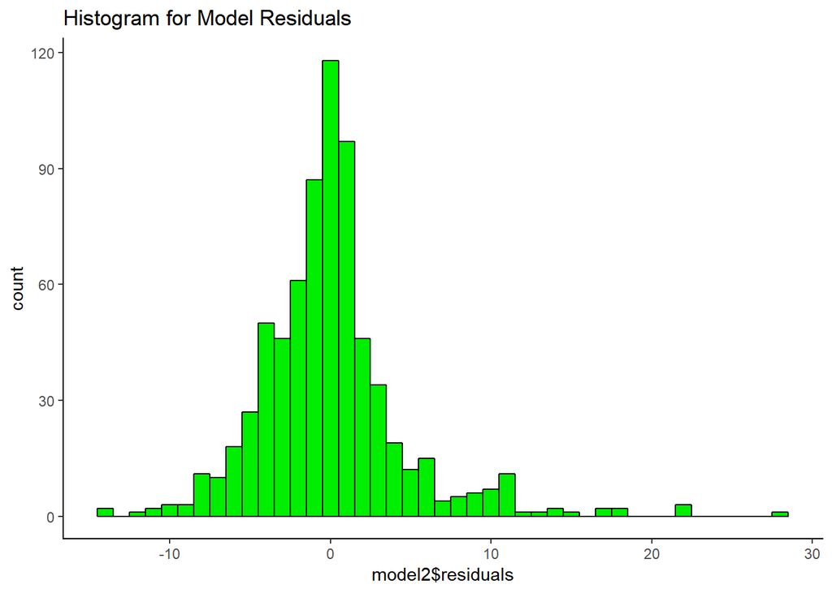

Histogram to visualize model3

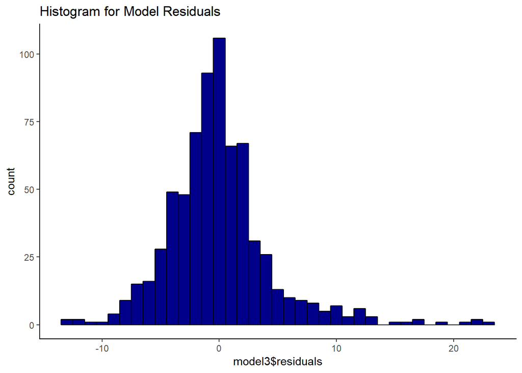

Scatter plot of BMI_s1 vs. Liver Fat.

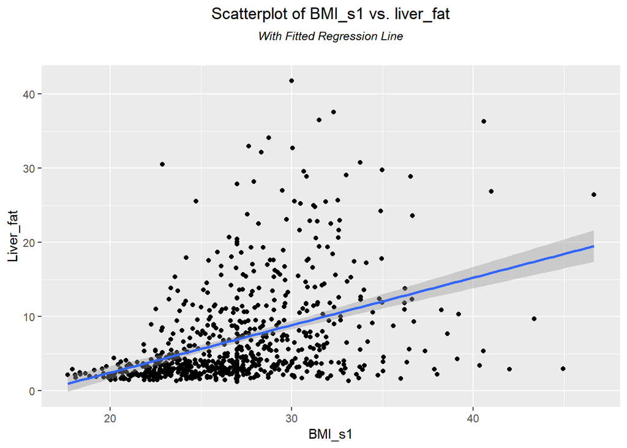

Accumulated Local Effects plot.

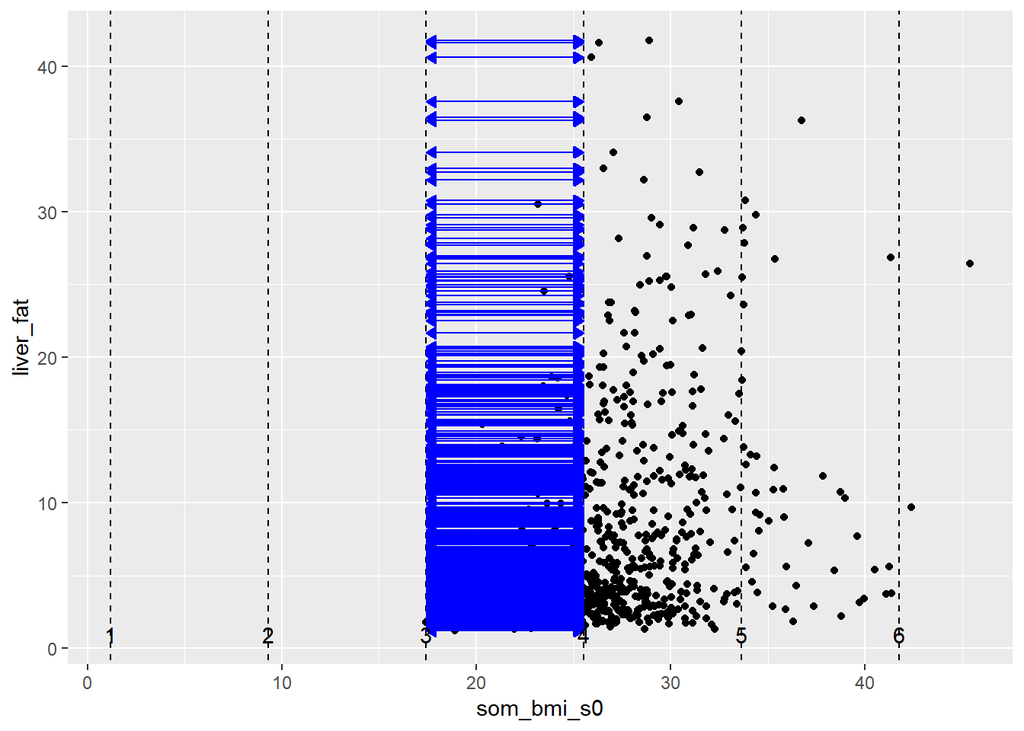